# Predicting Movements in Samsung Devices

Vinay

November 19, 2015

The project requires us to predict movement of six individuals based on the data captured by their samsung devices. The data set includes almost 20000 observations with 159 predictor variables.

The predictors are numerical and capture movement in particular direction i.e. roll , yaw etc.

## Reading data and Descriptive summary

We read the data and look at the data structure. A summary of the data tells us that the data for large number of variables is very sparse.

```r
rm(list = ls(all= TRUE))
library(caret)
traindata <- read.csv("C:/Users/Vinay/Desktop/Assignments to be done/Practical Machine learning/pml-training.csv", sep = ",", header = TRUE)

olddata <- traindata
#str(olddata)
#summary(olddata)
```

# Data Cleaning

1. As dicussed the dataset contains a large number of sparse data. These predictor contain a large number of NA values. Here I decide to remove these predictors.

```r
nlv <- nearZeroVar(traindata)
nlv
```

```
##  [1]   6  14  17  26  51  52  53  54  55  56  57  58  59  75  78  79  81
## [18]  82  89  92 101 127 130 131 134 137 139 142 143 144 145 146 147 148
## [35] 149 150
```

```r
traindata <- traindata[,-nlv]
```

2. I also look at the density of the predictor variables. I remove all predictors with more than 97 percent NA values

```r
ncol(traindata)
```

```
## [1] 124
```

```r
categorical <- c(2,5,124)
numerical <- setdiff(c(1:124), categorical)
empty = NULL
len <- length(traindata$X)

for (i in numerical){
  traindata[,i] <- as.integer(traindata[,i])

  if (sum(is.na(traindata[,i])) >= 0.97*len)
  {
    empty[length(empty) + 1] = i
  }
}

empty
```

```
##  [1]  11  12  13  14  15  16  17  18  19  20  21  22  23  24  25  26  27
## [18]  28  29  30  31  32  46  56  57  58  59  60  61  62  63  64  65  69
## [35]  70  71  72  73  74  75  76  77  78  79  80  82  83  84  85  86  87
## [52]  88  89  90  91 104 105 106 107 108 109 110 111 112 114
```

```r
traindata <- traindata[,-empty]
```

3. I remove the 12th column too as it contains all zeros

```r
ncol(traindata)
```

```
## [1] 59
```

```r
categorical <- c(2,5,59)
numerical <- setdiff(c(1:59), categorical)
traindata <- traindata[,-12]
numerical <- ncol(traindata)
numerical <- setdiff(1:58, c(12))

categorical <- c(2,5,58)
numerical <- setdiff(1:58, categorical)
numerical
```

```
##  [1]  1  3  4  6  7  8  9 10 11 12 13 14 15 16 17 18 19 20 21 22 23 24 25
## [24] 26 27 28 29 30 31 32 33 34 35 36 37 38 39 40 41 42 43 44 45 46 47 48
## [47] 49 50 51 52 53 54 55 56 57
```

4. Remove Highly Correlated predictors

We remove the highly correlated predictors. Our cutoff is 0.85. We use the caret package to get the indices of the columns to remove.

```r
CorrMatX <- round(cor(traindata[,numerical]),2)
#CorrMatX

highcorr <- findCorrelation(CorrMatX, cutoff = 0.85,verbose = FALSE)
traindata <- traindata[,-highcorr]
```

## Exploratory Study

WE try to study the relationships among these predictor variables and the target variable by looking at the pair wise plots. These plots allow us to see the variables and how effectively they can separate the target variable.

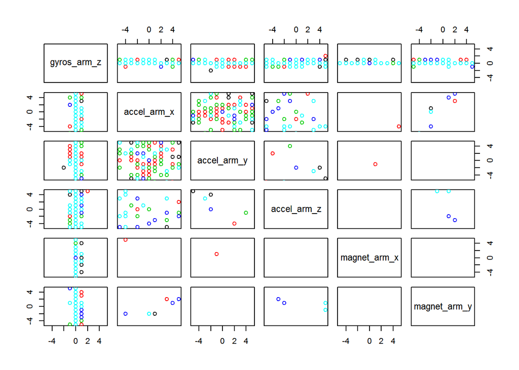

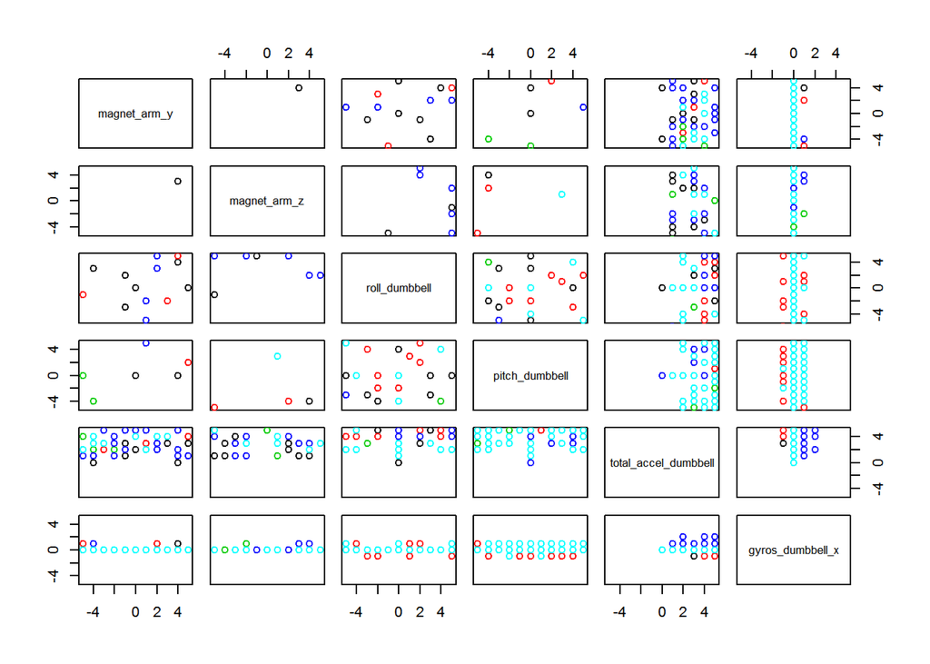

1. We separate the data set into training and testing dataset i.e. 70 percent and 30 percent.

```r
intrain <- createDataPartition(traindata$classe, p=0.7, list = FALSE)
train <- traindata[intrain,]
test <- traindata[-intrain,]
```

The out of sample error should be minimum once the data has been cleaned and model can effectively classify on the test data.

```r
predictions <- predict(modelone, newdata = test)
confusionMatrix(predictions,test$classe)
```

```
## Confusion Matrix and Statistics
##
##           Reference
## Prediction    A    B    C    D    E
##          A 1674    0    0    0    0
##          B    0 1139    0    0    0
##          C    0    0 1026    0    0
##          D    0    0    0  964    0
##          E    0    0    0    0 1082
##
## Overall Statistics
##
##                Accuracy : 1
##                  95% CI : (0.9994, 1)
##     No Information Rate : 0.2845
##     P-Value [Acc > NIR] : < 2.2e-16
##
##                   Kappa : 1
##  Mcnemar's Test P-Value : NA
##
## Statistics by Class:
##
##                      Class: A Class: B Class: C Class: D Class: E
## Sensitivity            1.0000   1.0000   1.0000   1.0000   1.0000
## Specificity            1.0000   1.0000   1.0000   1.0000   1.0000
## Pos Pred Value         1.0000   1.0000   1.0000   1.0000   1.0000
## Neg Pred Value         1.0000   1.0000   1.0000   1.0000   1.0000
## Prevalence             0.2845   0.1935   0.1743   0.1638   0.1839
## Detection Rate         0.2845   0.1935   0.1743   0.1638   0.1839
## Detection Prevalence   0.2845   0.1935   0.1743   0.1638   0.1839
## Balanced Accuracy      1.0000   1.0000   1.0000   1.0000   1.0000
```

## Conclusion

With this prediction method, we are able to achieve a high accuracy on hold out sample. We can use this model to classify movements for these six participants based on their device metrics.